# Analysis of NBA Regular Season to Predict Outcome of 2018 Playoffs

Chanel Aquino, Dario Molina, Evert Rodriguez

May 7, 2018

### Introduction / Objective

In this project, we will look into NBA Statistics data, and analyze in detail what this data represents. We will make graphs, to visually analyze and find patterns, to make a prediction of which two teams will make it to NBA Playoffs final.

For this project, we are using three different data sets. The data set championsdata.csv contains game-by-game team totals for the championship team from every finals game between 1980 and 2017. As well as runnerupsdata.csv contains game-by-game team totals for the runner-up team from every finals game between 1980 and 2017. The 1980 NBA Finals was the first Finals series since the NBA added the three point line. Both these data sets were downloaded from the NBA Finals Team Stats on Kaggle.com. The third data set NBATeamData.csv contains current regular season averages per game. This data set was obtained from NBA.com(http://stats.nba.com/teams/traditional/?sort=W_PCT&dir=-1&Season=2017-18&SeasonType=Regular%20Season), where it has records of each team in the NBA as early as the 1950s. The NBATeamData.csv has 1447 rows, 34 columns with a total amount of 49198 entries. It is updated weekly after every after every game played(only during nba season).

```r
> reg.ssn = read.csv("~/nba-playoffs-predictor/NBATeamData.csv", na.strings=c('N/A', 'NA'))
> champs = read.csv("~/nba-playoffs-predictor/nba-finals-team-stats/championsdata.csv", na.strings=c('N/A', 'NA'))
```

### Missing Data

```r
> # show NA percentages per column
> # data - a data frame
> show.na.pct = function(data) {
+   na.vals = apply(data, 2, function(x) mean(is.na(x)))
+   data.frame(na.vals)
+ }
```

#### Percentage of NA Valus in reg.ssn

```r
> show.na.pct(reg.ssn) * 100
```

```
                       na.vals
TEAM_ID                0.00000
TEAM_CITY              0.00000
TEAM_NAME              0.00000
YEAR                   0.00000
GP                     0.00000
WINS                   0.00000
LOSSES                 0.00000
WIN_PCT                0.00000
CONF_RANK              0.00000
DIV_RANK               0.00000
PO_WINS                0.00000
PO_LOSSES              0.00000
CONF_COUNT             0.00000
DIV_COUNT              0.00000
NBA_FINALS_APPEARANCE 90.39392
FGM                    0.00000
FGA                    0.00000
FG_PCT                 0.00000
FG3M                   0.00000
FG3A                   0.00000
FG3_PCT                0.00000
FTM                    0.00000
FTA                    0.00000
FT_PCT                 0.00000
OREB                   0.00000
DREB                   0.00000
REB                    0.00000
AST                    0.00000
PF                     0.00000
STL                    0.00000
TOV                    0.00000
BLK                    0.00000
PTS                    0.00000
PTS_RANK               0.00000
```

#### Percentage of NA Valus in champs

```r
> show.na.pct(champs) * 100
```

```
      na.vals
X    0.000000
Year 0.000000
Team 0.000000
Game 0.000000
Win  0.000000
Home 0.000000
MP   0.000000
FG   0.000000
FGA  0.000000
FGP  0.000000
TP   0.000000
TPA  0.000000
TPP  2.777778
FT   0.000000
FTA  0.000000
FTP  0.000000
ORB  0.000000
DRB  0.000000
TRB  0.000000
AST  0.000000
STL  0.000000
BLK  0.000000
TOV  0.000000
PF   0.000000
PTS  0.000000
```

```r
> reg.ssn[['nba_finals_appearance']] = NULL # remove nba_finals_appearance column
> champs = na.omit(champs)
```

### Preprocessing / Cleaning

```r
> names(reg.ssn) = tolower(names(reg.ssn))
> names(champs) = tolower(names(champs))
```

Column **x** in the **champs** data set was removed as values in this column merely uniquely identified rows and did not provide valuable information. Also, some columns from the **reg.ssn** data set were also removed

```r
> # columns not needed
> champs[['x']] = NULL
> reg.ssn[['team_id']] = NULL
> reg.ssn[['team_city']] = NULL
> reg.ssn[['conf_rank']] = NULL
> reg.ssn[['conf_count']] = NULL
> reg.ssn[['div_rank']] = NULL
> reg.ssn[['div_count']] = NULL
> reg.ssn[['pts_rank']] = NULL
```

Here, we renamed the column names in the **reg.ssn** data set to match the column names in the **champs** data set.

```r
> # change reg.ssn column names to match champs and r.ups column names
> names(reg.ssn)[1] = 'team'
> names(reg.ssn)[10] = 'fg' # field goals made
> names(reg.ssn)[12] = 'fgp' # field goal percentage
> names(reg.ssn)[13] = 'tp' # 3-point field goals made
> names(reg.ssn)[14] = 'tpa' # 3-point field goals attempted
> names(reg.ssn)[15] = 'tpp' # 3-point percentage
> names(reg.ssn)[16] = 'ft' # free throws made
> names(reg.ssn)[18] = 'ftp' # free throw percentage
> names(reg.ssn)[19] = 'orb' # offensive rebounds
> names(reg.ssn)[20] = 'drb' # defensive rebounds
> names(reg.ssn)[21] = 'trb' # total rebounds
```

We also fixed some spelling errors in some columns as well as created a new column **ot** in the **champs/r.ups** data set that would indicate whether a game went into overtime or not (true if value in the **minutes played (mp)** column > 240).

```r
> unique(champs$team)
```

```
 [1] Lakers    Celtics   Sixers    Pistons   Bulls     Rockets   Spurs
 [8] Heat      Mavericks 'Heat'    Warriors  Cavaliers Warriorrs
13 Levels: 'Heat' Bulls Cavaliers Celtics Heat Lakers ... Warriors
```

```r
> # fix spelling errors
> champs$team[champs$team == '\'Heat\''] = 'Heat'
> champs$team[champs$team == 'Warriorrs'] = 'Warriors'
> champs$team = factor(champs$team)
>
> # new column 'ot' to indicate whether game went into overtime
> champs$ot = FALSE
> champs$ot[champs$mp > 240] = TRUE
> champs[['mp']] = NULL
```

Finally, because the **reg.ssn** data set contained information dating back to 1946, we only kept rows that contained information from the past 10 years.

```r
> # keep only last 10 years of data
> pattern = '^20(0[789]|1[[:digit:]])'
> rows = grep(pattern, reg.ssn$year)
> reg.ssn = reg.ssn[rows, ]
```

### Variables in reg.ssn, champs, r.ups

| Column | Description |
| --- | --- |
| year | year the series was played |
| **gp** | **games played** |
| **wins** | **wins** |
| **losses** | **losses** |
| **win_pct** | **win percentage** |
| **po_wins** | **playoff wins** |
| **po_losses** | **playoff losses** |
| team | name of the team |
| game | game # |
| win | 1 = win, 0 = loss |
| home | 1 = home team, 0 = away team |
| fg | field goals made |
| fga | field goals attempted |
| fgp | field goal percentage |
| tp | 3-point field goals made |
| tpa | 3-point field goals attempted |
| tpp | 3-point field goal percentage |
| ft | free throws made |
| fta | free throws attempted |
| ftp | free throw percentage |
| orb | offensive rebounds |
| drb | defensive rebounds |
| trb | total rebounds |
| ast | assists |
| stl | steals |
| blk | blocks |
| tov | turnovers |
| pf | personal fouls |
| pts | points scored |
| ot | 1 = overtime, 0 = 240 minutes played |

### Analysis

From the correlation plot below, it is evident that there are strong linear correlations between field goals made (fg), assists (ast), and points scored (pts). There also seems to be a positive linear correlation (albeit a relatively weak one) between defensive rebounds (drb) and blocks (blk).

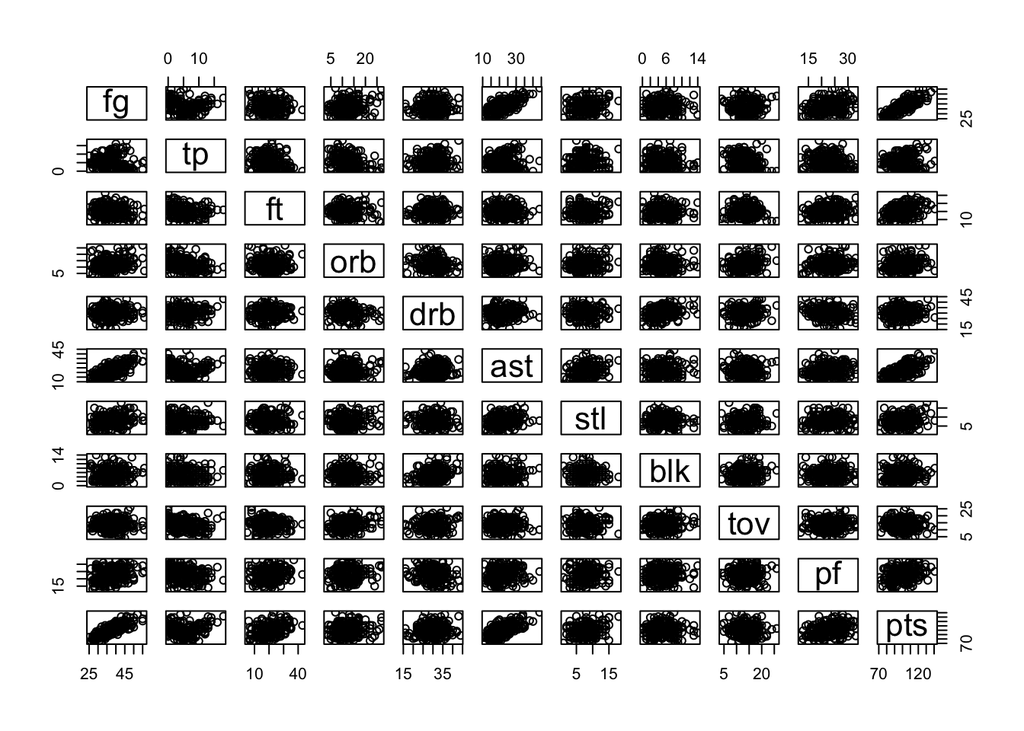

```r
> cols = c('fg', 'tp', 'ft', 'orb', 'drb', 'ast', 'stl', 'blk', 'tov', 'pf', 'pts')
> plot(champs[, cols]) # correlation between wins + other columns
```

```r
> cor(champs[,cols])
```

```
               fg          tp          ft         orb         drb
fg   1.0000000000 -0.16257477 -0.10657903  0.21843943  0.07471859
tp  -0.1625747695  1.00000000 -0.15461372 -0.31530755  0.06827922
ft  -0.1065790261 -0.15461372  1.00000000  0.02099666  0.08662767
orb  0.2184394332 -0.31530755  0.02099666  1.00000000 -0.08417883
drb  0.0747185942  0.06827922  0.08662767 -0.08417883  1.00000000
ast  0.7126927163 -0.05336447  0.01560324  0.08306198  0.10109843
stl  0.2630196743 -0.04518950  0.04051325  0.12149521 -0.01235721
blk  0.0637105740 -0.09402341  0.01763439  0.05108545  0.28682738
tov  0.0009140258 -0.21116913 -0.09075483  0.25331418  0.06378657
pf   0.2811111529 -0.15006278  0.15535152  0.17842254 -0.19352699
pts  0.8401342336  0.06052306  0.36926652  0.12422568  0.13509832
            ast         stl          blk           tov           pf
fg   0.71269272  0.26301967  0.063710574  0.0009140258  0.281111153
tp  -0.05336447 -0.04518950 -0.094023411 -0.2111691263 -0.150062783
ft   0.01560324  0.04051325  0.017634385 -0.0907548350  0.155351517
orb  0.08306198  0.12149521  0.051085453  0.2533141826  0.178422536
drb  0.10109843 -0.01235721  0.286827380  0.0637865748 -0.193526992
ast  1.00000000  0.26582150  0.094981845  0.0139187580  0.135535256
stl  0.26582150  1.00000000 -0.041124514  0.0818018411  0.044821980
blk  0.09498185 -0.04112451  1.000000000  0.1368769229  0.005303828
tov  0.01391876  0.08180184  0.136876923  1.0000000000  0.065503230
pf   0.13553526  0.04482198  0.005303828  0.0655032301  1.000000000
pts  0.66426173  0.25556768  0.041556641 -0.1078509131  0.301004541
            pts
fg   0.84013423
tp   0.06052306
ft   0.36926652
orb  0.12422568
drb  0.13509832
ast  0.66426173
stl  0.25556768
blk  0.04155664
tov -0.10785091
pf   0.30100454
pts  1.00000000
```

### Train / Test Sets

Here, we have created training and test sets for all the data set.

```r
> set.seed(123)
> tr.rows = sample(1:nrow(champs), .75*nrow(champs))
> tr.dat = champs[tr.rows,]
> te.dat = champs[-tr.rows,]
```

### Logistic Regression 1: fg, tp, ft, ast

From this model, we can see that the number of field goals and free throws made highly contribute to predicting the outcome of a game (i.e., win versus loss).

```r
> lg.fit1 = glm(win ~ fg + tp + ft + ast, data=tr.dat, family=binomial)
> summary(lg.fit1)
```

```
Call:
glm(formula = win ~ fg + tp + ft + ast, family = binomial, data = tr.dat)

Deviance Residuals:
    Min       1Q   Median       3Q      Max
-2.4657  -0.8568   0.4809   0.7721   1.7055

Coefficients:
            Estimate Std. Error z value Pr(>|z|)
(Intercept) -7.88843    1.86480  -4.230 2.34e-05 ***
fg           0.16180    0.05059   3.198  0.00138 **
tp           0.06952    0.05708   1.218  0.22328
ft           0.18607    0.03977   4.679 2.88e-06 ***
ast         -0.04691    0.04759  -0.986  0.32428
---
Signif. codes:  0 '***' 0.001 '**' 0.01 '*' 0.05 '.' 0.1 ' ' 1

(Dispersion parameter for binomial family taken to be 1)

    Null deviance: 189.91  on 156  degrees of freedom
Residual deviance: 153.45  on 152  degrees of freedom
AIC: 163.45

Number of Fisher Scoring iterations: 5
```

```r
> actual = te.dat$win
> predicted1 = predict(lg.fit1, newdata=te.dat, type='response')
```

### Logistic Regression 2: orb, drb, stl, blk, tov

From this model, we can see that the number of defensive rebounds, steals, and turnovers made highly contribute to predicting the outcome of a game (i.e., win versus loss).

```r
> lg.fit2 = glm(win ~ orb + drb + stl + blk + tov, data=tr.dat, family=binomial)
> summary(lg.fit2)
```

```
Call:
glm(formula = win ~ orb + drb + stl + blk + tov, family = binomial,
    data = tr.dat)

Deviance Residuals:
    Min       1Q   Median       3Q      Max
-2.6366  -0.5616   0.3475   0.6672   1.9567

Coefficients:
            Estimate Std. Error z value Pr(>|z|)
(Intercept) -4.65212    1.71228  -2.717  0.00659 **
orb         -0.02808    0.04771  -0.589  0.55619
drb          0.30319    0.06146   4.933 8.10e-07 ***
stl          0.23878    0.07902   3.022  0.00251 **
blk         -0.04567    0.08626  -0.529  0.59646
tov         -0.31446    0.07270  -4.325 1.52e-05 ***
---
Signif. codes:  0 '***' 0.001 '**' 0.01 '*' 0.05 '.' 0.1 ' ' 1

(Dispersion parameter for binomial family taken to be 1)

    Null deviance: 189.91  on 156  degrees of freedom
Residual deviance: 133.47  on 151  degrees of freedom
AIC: 145.47

Number of Fisher Scoring iterations: 5
```

```r
> predicted2 = predict(lg.fit2, newdata=te.dat, type='response')
```

### Model Assessment: Precision, Recall, and ROC Curves

Below, the true/false positive rates as well as the precision rates for both logistic regression models. The true positive rate indicates the rate at which positive outcomes were predicted positive (i.e., actual wins that were predicted as wins). False positive rates indicate wins that were falsely predicted (i.e., predicted win but actually a loss). The precision rate indicates the rate at which positive predictions were actually positive (i.e., predicted wins were actual wins).

```r
> thresh = seq(0, 1, length.out=50) # sequence of threshold values
> tpr1 = c() # true positive rate
> tpr2 = c()
> fpr1 = c() # false positive rate
> fpr2 = c()
> precision1 = c() # precision
> precision2 = c()
>
> for(t in thresh) {
+   # model 1
+   predicted = as.numeric(predicted1 > t)
+   precision1 = c(precision1, sum(predicted & actual)/sum(predicted))
+   tpr1 = c(tpr1, sum(predicted & actual)/sum(actual))
+   fpr1 = c(fpr1, sum(predicted == 1 & actual == 0)/sum(actual == 0))
+
+   # model 2
+   predicted = as.numeric(predicted2 > t)
+   precision2 = c(precision2, sum(predicted & actual)/sum(predicted))
+   tpr2 = c(tpr2, sum(predicted & actual)/sum(actual))
+   fpr2 = c(fpr2, sum(predicted == 1 & actual == 0)/sum(actual == 0))
+ }
```

As we can see from the precision-threshold graph below, the first logistic regression model (fg, tp, ft, ast as predictors) reached its highest precision rate (about 92%) when the threshold was about 90%. (This threshold means that when a game had a winning probablility of >= 90%, the outcome of the game was a win.) The second model (orb, drb, stl, blk, tov as predictors) reached its highest precision rate (about 94%) when the threshold was about 95%.

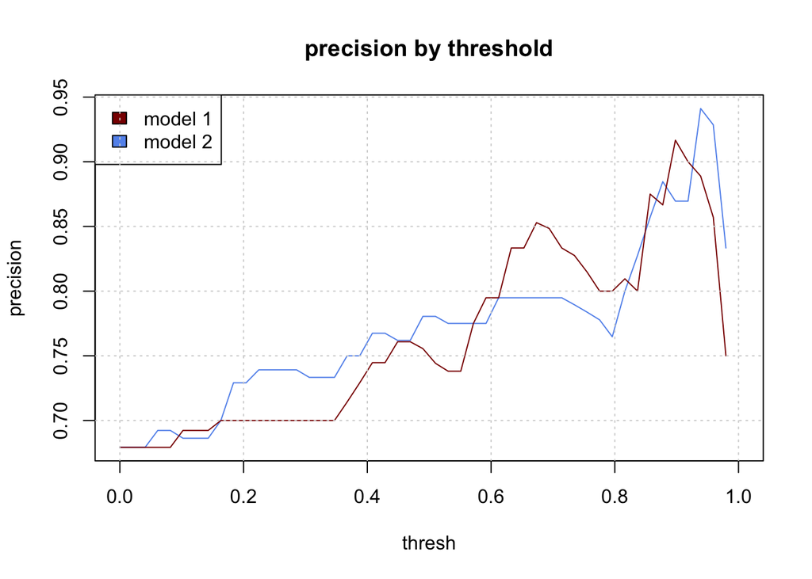

```r
> # precision by threshold
> plot(thresh, precision2, main='precision by threshold', col='cornflowerblue', type='l', xlab="thresh", ylab="precision")
> lines(thresh, precision1, col='red4', type="l")
> legend("topleft", fill=c('red4', 'cornflowerblue'), legend=c('model 1', 'model 2'))
> grid()
```

From the graph below, it is evident that recall rate (i.e., true positive rate) of both logistric regression models saw a decline when the threshold was around 50%.

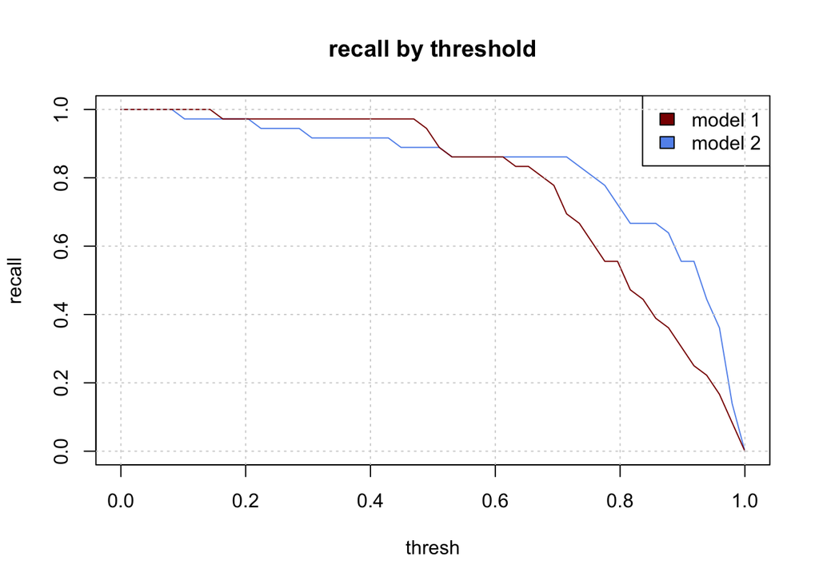

```r
> # recall (i.e., tpr) by threshold
> plot(thresh, tpr2, main='recall by threshold', col='cornflowerblue', type="l", ylab="recall", xlab="thresh")
> lines(thresh, tpr1, col='red4', type="l")
> legend("topright", fill=c('red4', 'cornflowerblue'), legend=c('model 1', 'model 2'))
> grid()
```

From the precision-recall curves below, we can see that model 2 shows a general inverse relationship between precision and recall. In other words, for our second logistic regression model, there is an overall decline in precision as recall rates increase.

The curve for model 1, overall, follows this same trend. However, there seems to be a visually anomalous area in the curve where a relatively high precision (about 85%) is paired with an also high recall rate (about 80%). Referring to the previous two graphs, we can see that these precision and recall rates can be achieved with a threshold value of about 70%.

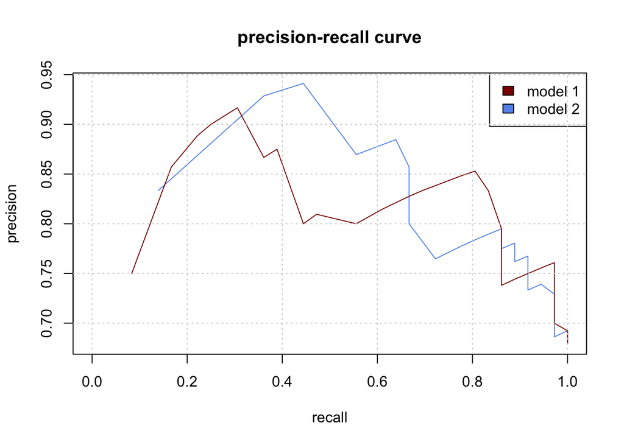

```r
> # precision-recall curve
> plot(tpr2, precision2, main="precision-recall curve", col='cornflowerblue', type="l", xlab="recall", ylab="precision")
> lines(tpr1, precision1, col='red4', type="l")
> legend("topright", fill=c('red4', 'cornflowerblue'), legend=c('model 1', 'model 2'))
> grid()
```

```r
> thresh = 0.70 # new threshold value
```

ROC curves show how true positive rates (TPR) and false positive rates (FPR) change as the threshold changes. The goal is to have a high TPR and low FPR. The curves below support this.

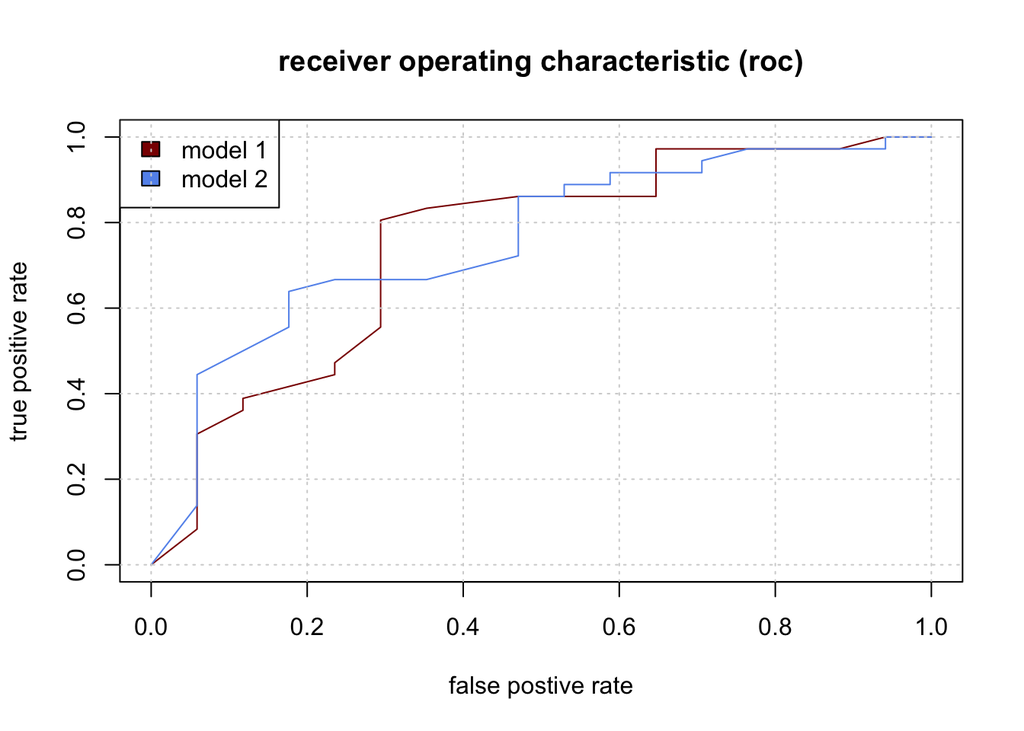

```r
> # roc curve
> plot(fpr1, tpr1, type="l", col='red4', main='receiver operating characteristic (roc)', xlab="false postive rate", ylab="true positive rate")
> lines(fpr2, tpr2, type="l", col='cornflowerblue', xlab="false postive rate", ylab="true positive rate")
> legend("topleft", fill=c('red4', 'cornflowerblue'), legend=c('model 1', 'model 2'))
> grid()
```

```r
> set.seed(132)
> library(rpart)
> library(rpart.plot)
> library(maptree)
> library(caret)
> reg.ssn$win = ifelse(reg.ssn$win_pct < 0.5 ,0,1)
> regularSeason = reg.ssn
```

### Data Visualization

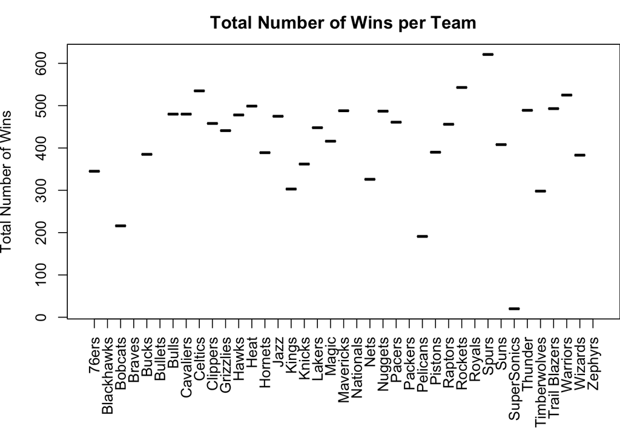

```r
> x = aggregate(wins ~ team, regularSeason,sum)
> par(mar=c(7,3.8,2.5,0))
> plot(x,las=3,type='s',xlab=" ",ylab="Total Number of Wins", main="Total Number of Wins per Team")
```

Some Important attributes from data set

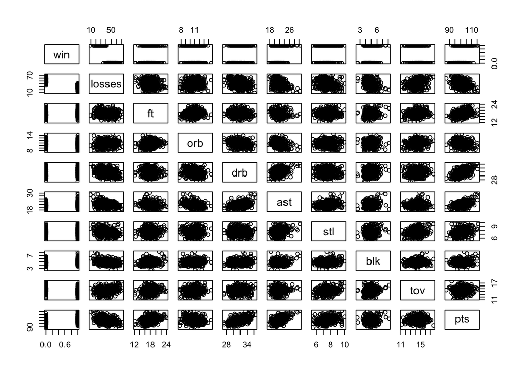

```r
> cols = c('win','losses', 'ft', 'orb', 'drb', 'ast', 'stl', 'blk', 'tov', 'pts')
> plot(regularSeason[,cols])
```

```r
> cor(regularSeason[,cols])
```

```
              win     losses          ft         orb         drb
win     1.0000000 -0.8287549  0.15829151 -0.14578205  0.29457108
losses -0.8287549  1.0000000 -0.16615424  0.12644947 -0.32004928
ft      0.1582915 -0.1661542  1.00000000  0.14683034 -0.04917063
orb    -0.1457820  0.1264495  0.14683034  1.00000000 -0.30174361
drb     0.2945711 -0.3200493 -0.04917063 -0.30174361  1.00000000
ast     0.2627302 -0.3291844 -0.11701019 -0.32793529  0.39628097
stl     0.1934845 -0.2136005  0.04474678 -0.01381814 -0.04350293
blk     0.2254445 -0.2911702  0.14907315  0.05969934  0.17705202
tov    -0.2545710  0.2743156  0.14654336  0.16778364  0.02625215
pts     0.3447238 -0.3804292  0.33975098 -0.21266732  0.57786693
               ast         stl         blk          tov          pts
win     0.26273022  0.19348447  0.22544446 -0.254570982  0.344723775
losses -0.32918442 -0.21360048 -0.29117016  0.274315560 -0.380429159
ft     -0.11701019  0.04474678  0.14907315  0.146543362  0.339750980
orb    -0.32793529 -0.01381814  0.05969934  0.167783642 -0.212667322
drb     0.39628097 -0.04350293  0.17705202  0.026252150  0.577866932
ast     1.00000000  0.28540045  0.14633306  0.046988426  0.556375688
stl     0.28540045  1.00000000  0.13072270  0.218623217  0.284358912
blk     0.14633306  0.13072270  1.00000000  0.144620336  0.105890822
tov     0.04698843  0.21862322  0.14462034  1.000000000  0.008261598
pts     0.55637569  0.28435891  0.10589082  0.008261598  1.000000000
```

### Building Classification Tree

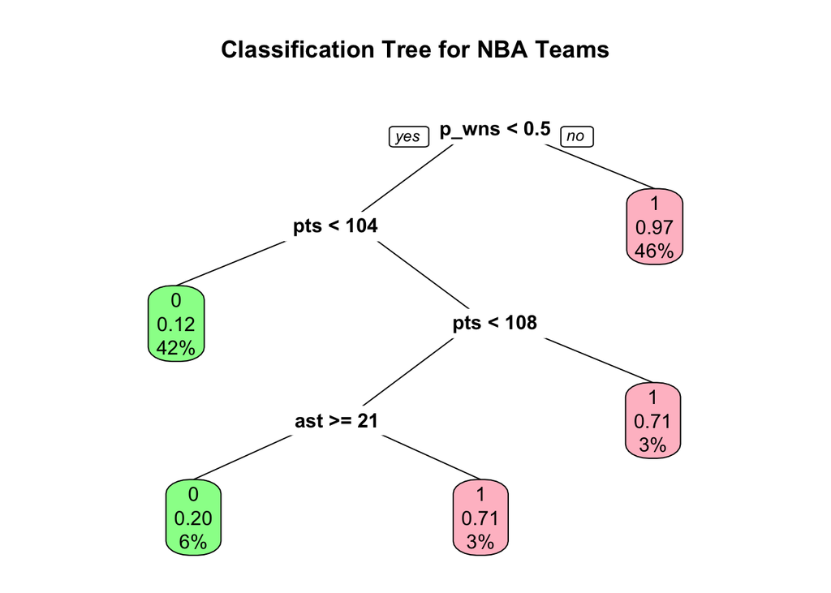

```r
> tr_rows = sample(1:nrow(regularSeason), .75*nrow(regularSeason))
> tr_dat = regularSeason[tr_rows,]
> te_dat = regularSeason[-tr_rows,]
>
> treeFit = rpart(win ~ gp + po_wins + pts + + ast,data=tr_dat, method="class")
>
> #treeFit = rpart(win ~ fg + tp + ft + ast, data=tr_dat, method="class")
>
> prp(treeFit, extra=106, varlen=5,
+  main="Classification Tree for NBA Teams",
+  box.col=c("palegreen", "pink")[treeFit$frame$yval])
```

### Classifying Test Data

```r
> predicted = predict(treeFit, te_dat, type="prob")
> predictors = as.data.frame(predicted)
> names(predictors) = c("zero","one")
> y = predictors$one
> predicts = as.numeric(y > 0.5)
> actuals = te_dat$win
> confusion_matrix=table(actuals, predicts)
> confusion_matrix
```

```
       predicts
actuals  0  1
      0 33  3
      1  4 43
```

```r
>  succ_rate = mean(predicts == actuals)
>  round(succ_rate, 3)
```

```
[1] 0.916
```